# Solar Energy Forecast

Jakub Tłuczek

4 02 2022

## Abstract

Following is the forecast of the total energy produced by a solar panel installation in eastern Poland. Data is collected monthly, with several exceptions whenever an inverter got broken and it wasn’t possible to retrieve energy produced last month. Additionaly, data about amount of energy bought and sold each month is also included. Aim of this task is to predict the production of energy in the following year. This task has been done in order to test newly acquired knowledge in a real life use case.

## Setup

Firstly, a dataset has to be loaded into environment. As raw data is being put in on a monthly basis in simple csv file, it is read in a following way:

```r
energia <- read.table("energia.csv", sep=";", header=T)
energia <- energia %>%
  mutate(month = yearmonth(Data)) %>%
  select(-Data)%>%
  as_tsibble(index = month)
```

Aside from loading the table, `Data` which is in a `%y-%m-%d` format is being replaced by `month` variable, which is then set to an index of a resulting `tsibble`.

## Preprocessing

Dataset includes several missing values, which have to be imputed in order to proceed. Since there has been no significant weather anomalies regarding suntime in eastern Poland, a seasonal split has been used:

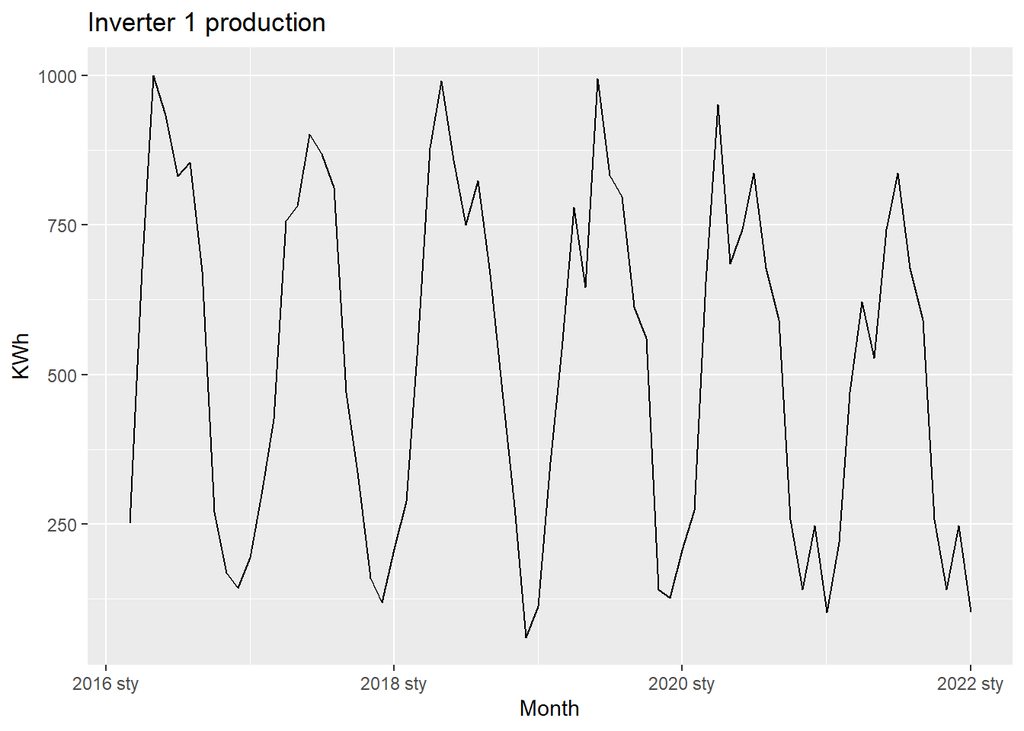

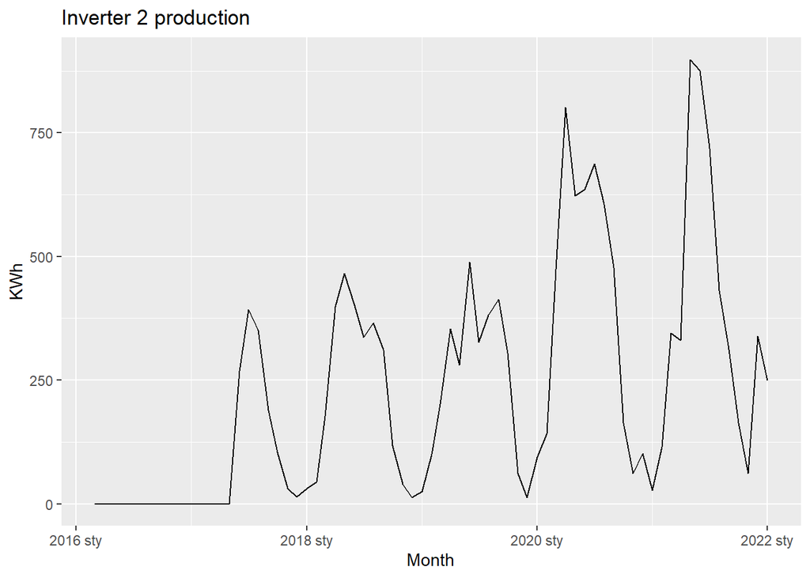

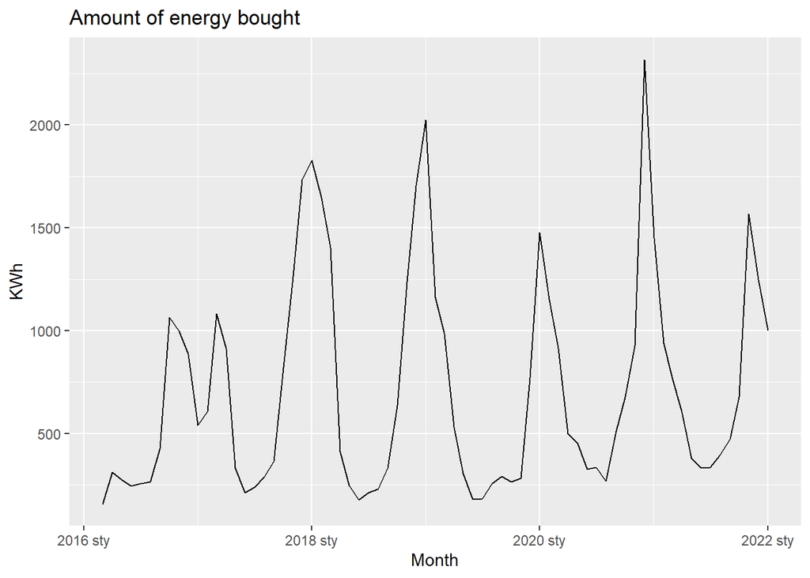

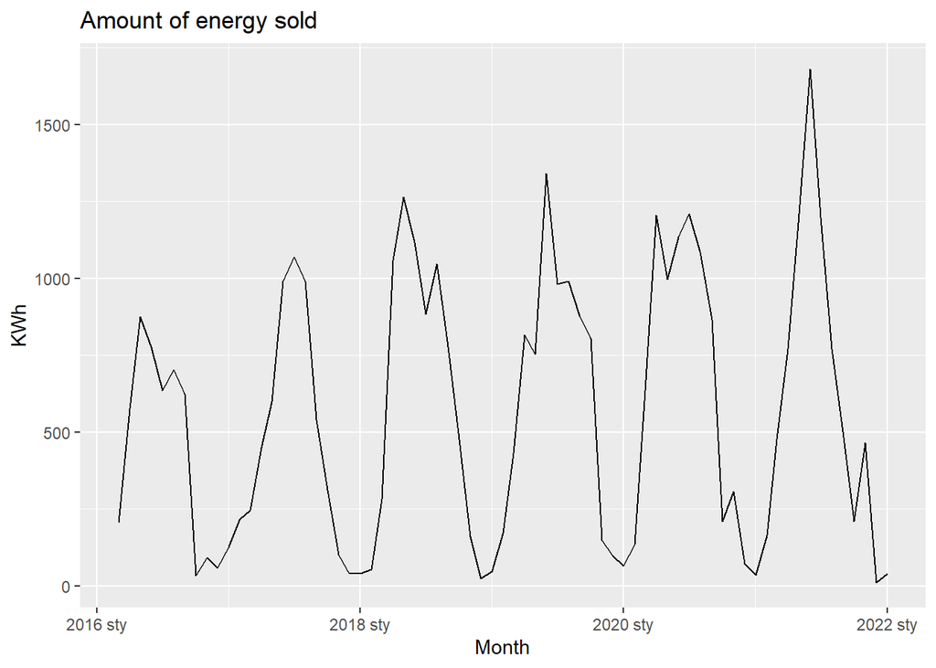

In all variables a strong seasonal trend can be noticed, where production and energy sold peaks during summer, while the amount of energy bought is noticeably higher during winter.

In the next step two calculated variables were added, namely balance of energy sold/bought, and monthly sum of energy produced.

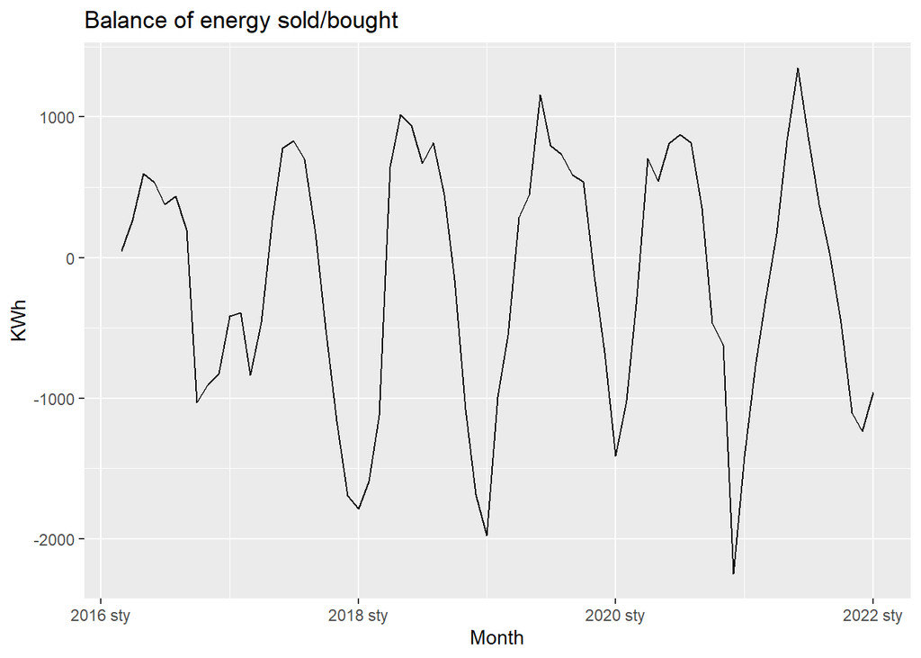

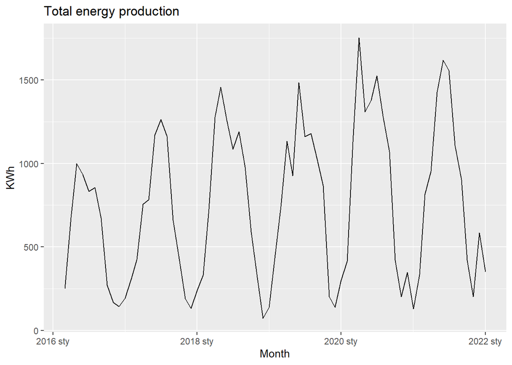

```r
energia %>%
  mutate(ProdukcjaRazem = Produkcja1 + Produkcja2,
         Bilans = Sprzedaz - Zakup) -> energia
```

## Exploration

To make sure that data is indeed seasonal, which would be a valuable information in the following steps, following seasonal plots were examined:

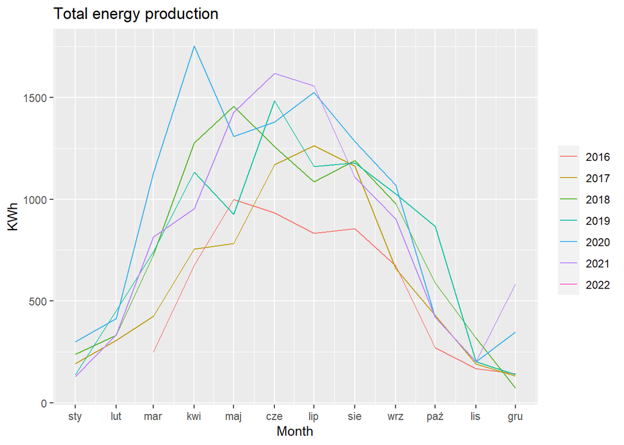

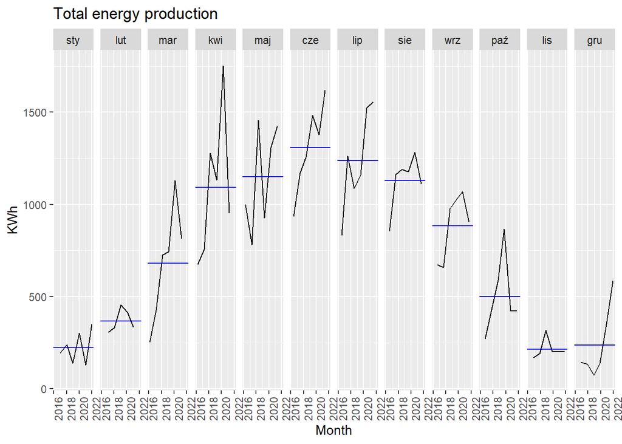

As shown in the figures above, strong seasonal trend in energy production occuring in summer is clearly seen, and frankly expected - summer in northern hemisphere, and thus the most suntime, occurs in the middle of the year. Slight growing trend can also be noticed in second figure, which can be further confirmed by STL decomposition:

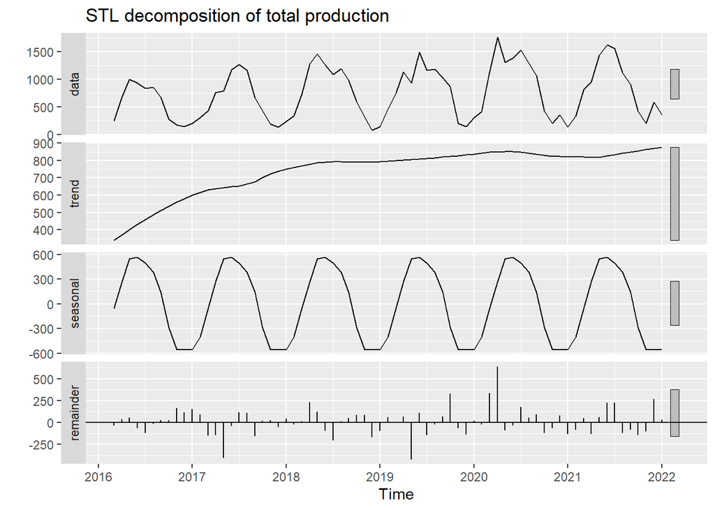

There is a slightly growing trend indeed, and remainders are in tolerable range - bigger values in March and April 2020 usually raise some questions about the correlation with the pandemic outburst and first lockdowns, yet in this case it just means that these two months were unusually sunny.

## Forecasts

With preprocessing and exploration done, the next step is to forecast data for upcoming months - using ARIMA, ETS and NNAR methods. In order to NNAR to work with external regressor, values of transaction balance were predicted independently, as they are not yet known.

### ARIMA

To find out which parameters would be good enough for non-seasonal and seasonal parts of ARIMA model, options `stepwise` and `approximation` were turned off - the best model turned out to be `ARIMA(0,0,1)(1,1,0)` with drift.

```r
energia %>%
  model(auto = ARIMA(ProdukcjaRazem, stepwise = F, approximation = F)) -> fit_ari

forecast(fit_ari, h=12) %>%
  filter(.model=='auto') %>%
  hilo() %>%
  select(-ProdukcjaRazem,-.model)
```

```
## # A tsibble: 12 x 4 [1M]
##       month .mean                     `80%`                     `95%`
##       <mth> <dbl>                    <hilo>                    <hilo>
##  1 2022 lut  473. [ 216.19788,  729.1559]80 [  80.42608,  864.9277]95
##  2 2022 mar 1108. [ 837.51988, 1378.6831]80 [ 694.28263, 1521.9203]95
##  3 2022 kwi 1518. [1247.61602, 1788.7792]80 [1104.37877, 1932.0165]95
##  4 2022 maj 1477. [1206.65665, 1747.8199]80 [1063.41940, 1891.0571]95
##  5 2022 cze 1601. [1330.35268, 1871.5159]80 [1187.11543, 2014.7531]95
##  6 2022 lip 1655. [1384.80535, 1925.9686]80 [1241.56810, 2069.2058]95
##  7 2022 sie 1324. [1053.69815, 1594.8614]80 [ 910.46090, 1738.0986]95
##  8 2022 wrz 1113. [ 842.65933, 1383.8225]80 [ 699.42208, 1527.0598]95
##  9 2022 paź  539. [ 268.72114,  809.8844]80 [ 125.48390,  953.1216]95
## 10 2022 lis  319. [  48.72114,  589.8844]80 [ -94.51610,  733.1216]95
## 11 2022 gru  571. [ 300.03229,  841.1955]80 [ 156.79504,  984.4327]95
## 12 2023 sty  344. [  73.43032,  614.5935]80 [ -69.80693,  757.8308]95
```

Corresponding plot:

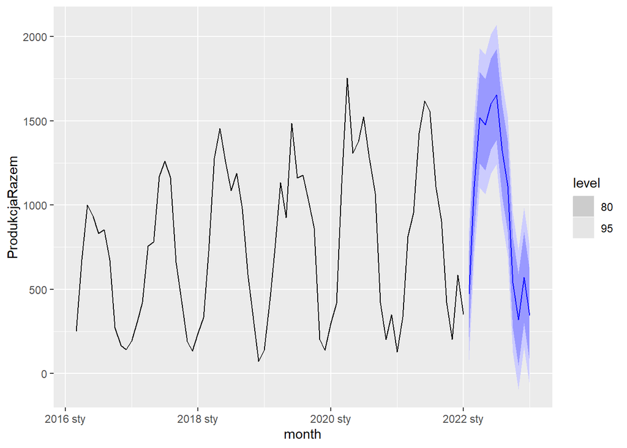

### ETS

Since data is seasonal, appropriate ETS method to deal with is Holt-Winters method. To select the one that doesn’t under- or overestimate, three methods have been checked - additive, multiplicative, and multiplicative with damping:

```r
prodr <- ts(energia$ProdukcjaRazem, start = c(2016,3), frequency = 12)
ets_add <- hw(prodr, seasonal = "additive")
ets_mul <- hw(prodr, seasonal = "multiplicative")
ets_dmp <- hw(prodr, damped = T, seasonal = "multiplicative")
```

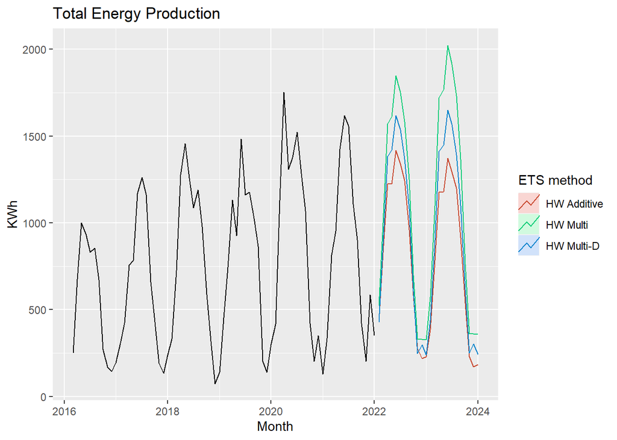

The most stable method of these three seems to be multiplicative with damping, and it is going to be considered from here on. It is not too optimistic as mulitplicative method without damping, nor it is decaying too much with time, contrary to an observed trend.

```r
ets_dmp %>% forecast(h=12)
```

```
##          Point Forecast    Lo 80     Hi 80     Lo 95     Hi 95
## Feb 2022       427.7523 252.8246  602.6799 160.22349  695.2810
## Mar 2022       879.4450 519.7066 1239.1833 329.27267 1429.6173
## Apr 2022      1383.0841 817.1849 1948.9832 517.61603 2248.5521
## May 2022      1420.2641 839.0014 2001.5268 531.29947 2309.2287
## Jun 2022      1618.5201 955.9454 2281.0949 605.19947 2631.8408
## Jul 2022      1537.1846 907.7411 2166.6280 574.53386 2499.8353
## Aug 2022      1366.5036 806.8028 1926.2044 510.51512 2222.4921
## Sep 2022      1081.5649 638.4538 1524.6760 403.88492 1759.2449
## Oct 2022       605.2379 357.2094  853.2665 225.91105  984.5648
## Nov 2022       246.1042 145.2230  346.9855  91.81967  400.3888
## Dec 2022       297.1411 175.3066  418.9757 110.81123  483.4710
## Jan 2023       238.3364 140.5868  336.0860  88.84128  387.8316
```

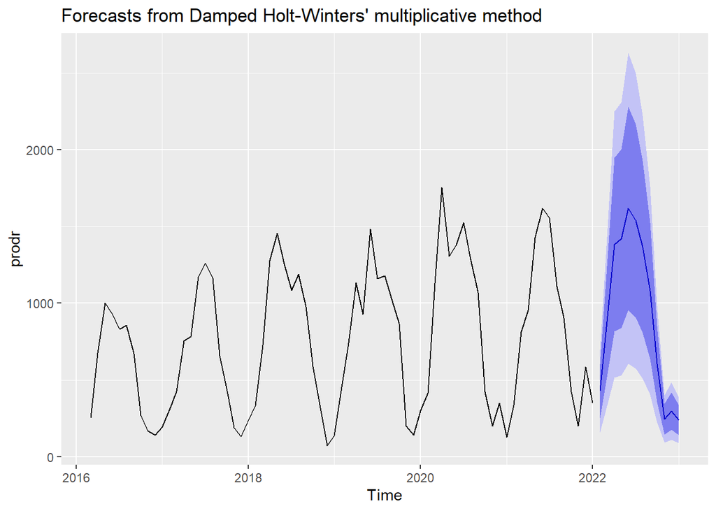

Though the forecast itself looks very similar to the one produced with ARIMA, the prediction intervals are much larger.

### NNAR

Last method used in the forecast is Neural Network Autoregression Model, which is not expected to outperform ARIMA - neural networks tend to have hard time working with trending data, and although an external regressor can help greatly with explaining the data, to forecast we should have new values for this regressor. To bypass that, future values of Balance, which was chosen to be a regressor, have been independently forecasted. Each of 20 networks produced each time is then averaged to produce final model. Forecast without an external regressor:

```r
fitnn <- nnetar(prodr)
nnetforecast <- forecast(fitnn, h=12, PI = T)
nnetforecast
```

```
##          Point Forecast      Lo 80     Hi 80      Lo 95     Hi 95
## Feb 2022       375.7833  109.43114  640.3140  -48.53276  755.4404
## Mar 2022       930.4630  656.85483 1195.0118  515.58579 1331.0687
## Apr 2022      1080.3106  832.18658 1356.0297  690.30018 1483.2605
## May 2022      1211.3518  956.27490 1483.6269  822.00318 1637.8427
## Jun 2022      1272.7609 1017.09427 1557.6026  870.19871 1711.0480
## Jul 2022      1283.7080 1021.18115 1584.0654  880.84398 1732.9416
## Aug 2022      1229.5235  971.04205 1502.6254  840.51423 1637.9474
## Sep 2022      1141.6209  876.00268 1408.8244  758.88824 1559.6333
## Oct 2022       543.3911  254.06678  817.2879  121.58438  953.5365
## Nov 2022       275.7727   16.66244  551.5394 -115.25617  690.7947
## Dec 2022       745.5376  487.21385  996.3297  357.95100 1147.5009
## Jan 2023       395.0676  163.83462  673.7326  -20.48973  830.7516
```

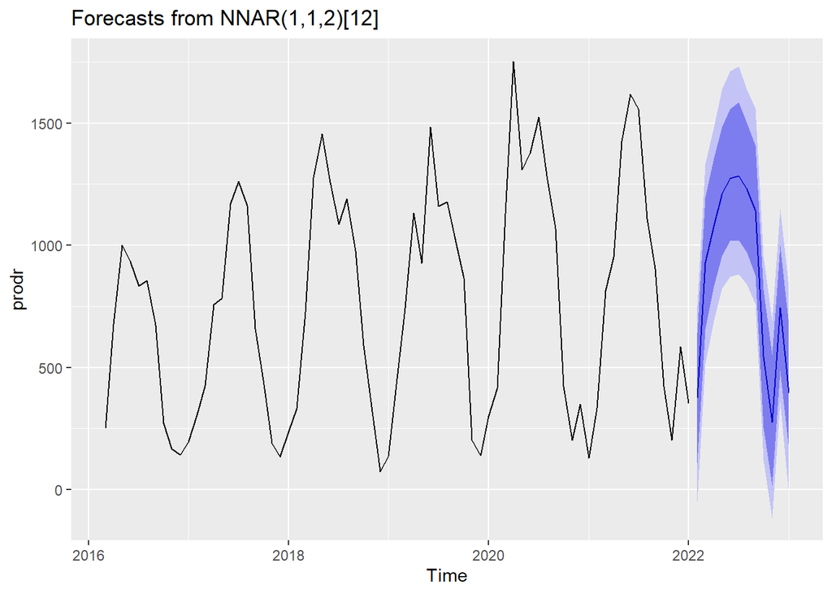

```r
autoplot(nnetforecast)
```

```r
fitnn2 <- nnetar(prodr, xreg = energia$Bilans)
balance_forecast <- c(-964.29,-588.84,213.32,638.36,923.74,789.57,698.11,361.37,-363.04,-827.66,-1507.65,-1375.54)
nnetforecast2 <- forecast(fitnn2, PI=T, xreg = balance_forecast)
nnetforecast2
```

```
##          Point Forecast     Lo 80     Hi 80      Lo 95     Hi 95
## Feb 2022       380.1061  192.0628  550.9526   97.23043  643.3078
## Mar 2022       734.5893  553.7545  917.3478  468.21240 1013.5375
## Apr 2022       895.0408  718.7886 1080.6484  608.96531 1164.0410
## May 2022      1230.2438 1051.0464 1410.6878  952.75591 1503.2283
## Jun 2022      1441.2017 1258.1252 1616.9297 1160.33107 1696.4263
## Jul 2022      1382.6818 1198.3247 1569.6113 1089.17862 1677.3153
## Aug 2022      1261.6168 1083.9710 1447.4099  990.73870 1562.8468
## Sep 2022       983.2848  790.2580 1173.6121  696.55415 1278.4967
## Oct 2022       376.7296  205.4949  591.8083  107.82058  681.0881
## Nov 2022       309.1266  135.2349  498.1626   38.24354  589.9893
## Dec 2022       517.0953  336.5024  675.3049  225.74827  781.4667
## Jan 2023       316.3599  136.0192  494.8232   55.49485  582.2151
```

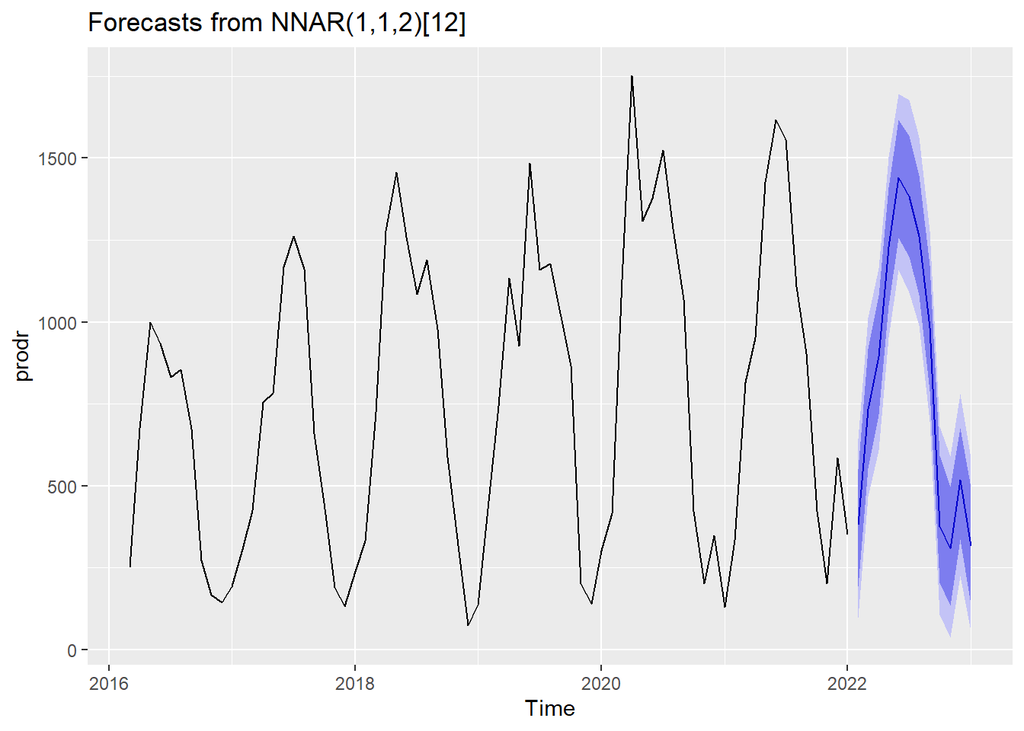

```r
autoplot(nnetforecast2)
```

It’s interesting to see how one variable can narrow the prediction intervals, and how much accuracy one can gain by knowing it beforehand.